# FetalBrain - Summary

Gloria Li

October 21, 2014

Updated: Thu Oct 23 11:59:50 2014

## Introduction

### Neurospheres Cortex vs GE

- Genetic mutations to epigenetic regulators and epigenomic alterations are amongst the earliest events in brain cell transformation. [PMID: 18772396](http://www.ncbi.nlm.nih.gov/pubmed/18772396)
- Defining the epigenomic landscape of normal human brain cells is an important first step towards defining the degree of epigenomic deregulation associated with transformation.
- Neurospheres provide a powerful model to study neural stem cells, which are thought to be population from which malignant clones arise.
- Little is known about epigenetic differences that define neurospheres emerged from distinct brain regions.

### MZ twins

- The genomes of monozygotic twins are genetically identical but epigenetically distinct providing evidence for the influence of environment on the phenotype.
- When these epigenetic differences arise during development and their consequence is still unknown.

## Results

### Neurospheres Cortex derived vs GE derived

#### Asymmetry between Cortex and GE UMRs

| Sample | Total.DMR | Hyper.DMR | Hypo.DMR |
| --- | --- | --- | --- |
| Cortex-HuFNSC02_GE-HuFNSC02 | 2178 | 420 | 1758 |
| Cortex-HuFNSC04_GE-HuFNSC04 | 646 | 91 | 555 |

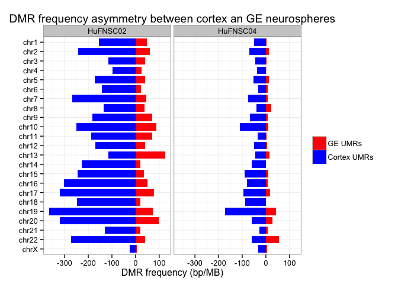

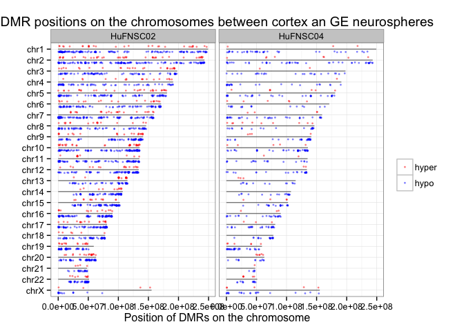

#### GREAT analysis on Cortex and GE UMRs show brain development terms

- UMRs in both Cortex and GE show enrichment in **neuron fate commitment** biological process, **transcriptional regulation** activities, **Homeobox** protein domain, and **abnormal brain development** mouse phenotype.
- Cortex UMRs are also enriched in **forebrain regionalization** and **pattern specification** processes.
- GREAT enriched terms are also **supported by MeDIP**.
- In HuFNSC04, Cortex UMRs show **abnormal brain development** in Mouse Phenotype, but are also enriched in **kidney-related processes**.

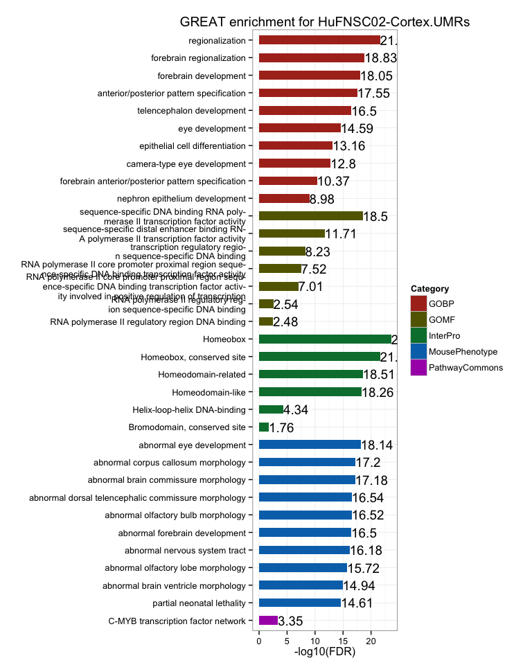

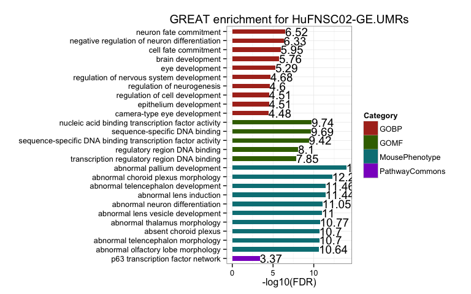

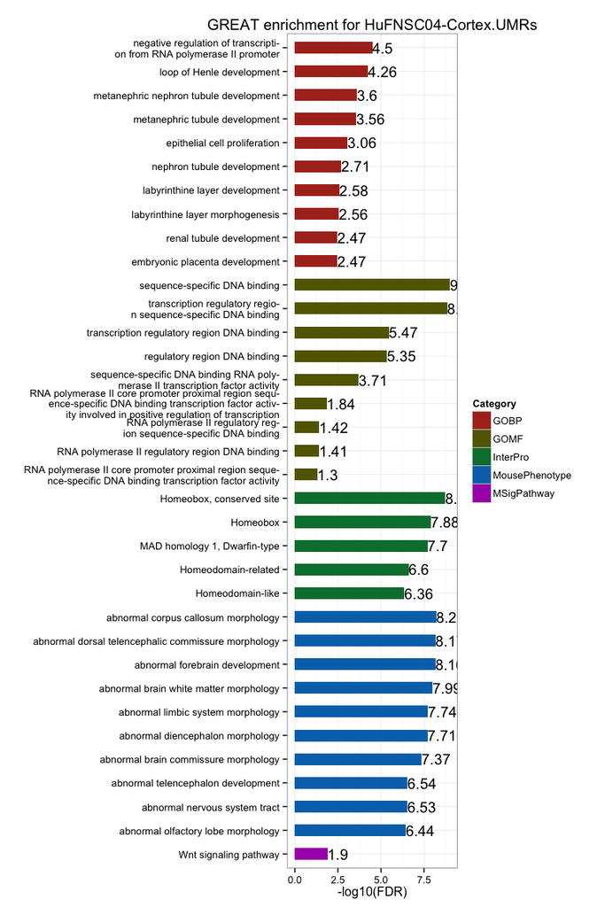

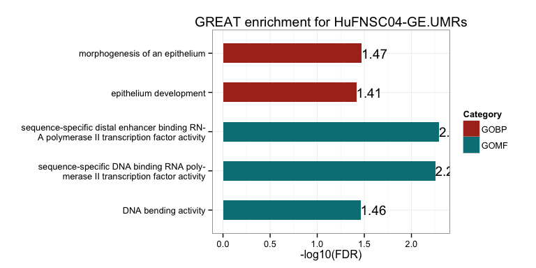

#### UMR breakdown in chromatin states - *TBC*

- **Pending: ChromHMM**

#### DE genes with proximal UMRs show key factors in brain development

- On average, there are **40** UMRs proximally associated with protein-coding genes (TSS +/- 1500bp), **2.85%** of all UMRs.
- There are average **8** proximal UMRs associated with DE genes, **19.88%** of all proximal UMRs, **much lower than observed in breast and supported by MeDIP**, *maybe more UMRs in enhancers? (ChromHMM)*. Among them, there are **46.67%** unique DE genes change in the same direction as the UMRs, **also lower than observed in breast and supported by MeDIP**.
- The intersect between two individuals are **significant** in Cortex UMRs. There are 3 DE genes with proximal Cortex UMR that are shared by both individual:
  - **GFAP**: Glial Fibrillary Acidic Protein. It is used as a marker to distinguish astrocytes from other glial cells during development. Reported associated with many brain disease, including alexanders disease, [PMID: 11567214](http://www.ncbi.nlm.nih.gov/pubmed?cmd=search&term=11567214&dopt=b); gliomas, UP reduce tumor and induce differentiation, [PMID: 15498217](http://www.ncbi.nlm.nih.gov/pubmed?cmd=search&term=15498217&dopt=b), and astrocytoma, tumor suppressor [PMID: 8339269](http://www.ncbi.nlm.nih.gov/pubmed?cmd=search&term=8339269&dopt=b) etc.
  - **NFIX**: Nuclear Factor I/X (CCAAT-Binding Transcription Factor). *Also supported by MeDIP.* A transcription factor that binds the palindromic sequence in viral and cellular promoters, capable of activating transcription and replication. It is essential for the development of a number of organ systems including brain and bone, e.g. severe neuroanatomical defects (may function in the repression of neural stem cell proliferation or in cell migration) [PMID: 18477394](http://www.ncbi.nlm.nih.gov/pubmed/18477394), [PMID: 19058033](http://www.ncbi.nlm.nih.gov/pubmed/19058033).
  - **FEZF1**: FEZ Family Zinc Finger 1 (ZNF312B). Transcription repressor. Involved in the axonal projection and proper termination of olfactory sensory neurons. Regulates non-cell-autonomously the layer formation of the olfactory bulb development and the interneurons. May be required for correct rostral migration of the interneuron progenitors. DNA demethylation and histone acetylation in its promoter activates its expression and oncogene effect in gastric cancer [PMID: 19318583](http://www.ncbi.nlm.nih.gov/pubmed?cmd=search&term=19318583&dopt=b). *We observe DN-regulation in Cortex and Cortex UMR though.*
- There are no intersect in pc genes with proximal GE UMRs between the two individual.
- There are **no significant** DAVID enrichment terms due to the small number of genes.

|  | proximal.UMRs | unique.genes | DE.DMRs | unique.DE.genes | same.direction |
| --- | --- | --- | --- | --- | --- |
| GE_UMRs-HuFNSC02 | 17 | 17 | 4 | 4 | 1 |
| Cortex_UMRs-HuFNSC02 | 53 | 52 | 15 | 14 | 8 |
| GE_UMRs-HuFNSC04 | 9 | 11 | 3 | 3 | 2 |
| Cortex_UMRs-HuFNSC04 | 82 | 84 | 10 | 9 | 3 |

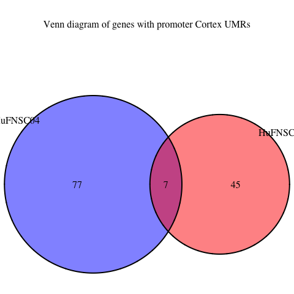

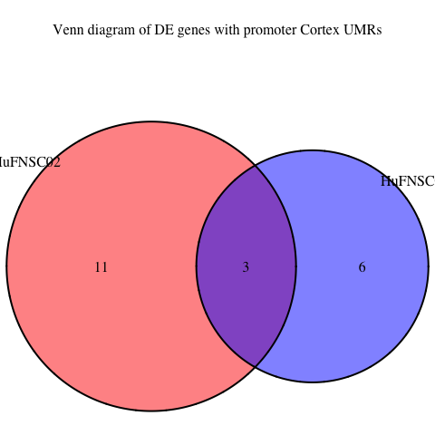

##### DE genes with proximal Cortex UMRs

- HuFNSC02

| name | description | DE |
| --- | --- | --- |
| CD58 | CD58_molecule | UP |
| RGS10 | regulator_of_G-protein_signaling_10 | UP |
| ADM | adrenomedullin | UP |
| NKX2-1 | NK2_homeobox_1 | DN |
| OTX2 | orthodenticle_homeobox_2 | DN |
| USP43 | ubiquitin_specific_peptidase_43 | DN |
| GFAP | glial_fibrillary_acidic_protein | UP |
| NFIX | nuclear_factor_I/X_(CCAAT-binding_transcription_factor) | UP |
| GAD1 | glutamate_decarboxylase_1_(brain,_67kDa) | DN |
| FZD7 | frizzled_family_receptor_7 | UP |
| FZD5 | frizzled_family_receptor_5 | DN |
| CXCR7 | chemokine_(C-X-C_motif)*receptor*7 | DN |
| ZAR1 | zygote_arrest_1 | UP |
| FEZF1 | FEZ_family_zinc_finger_1 | DN |

- HuFNSC04

| name | description | DE |
| --- | --- | --- |
| FAM5C | family_with_sequence_similarity_5,*member*C | UP |
| STXBP6 | syntaxin_binding_protein_6_(amisyn) | DN |
| GFAP | glial_fibrillary_acidic_protein | UP |
| NFIX | nuclear_factor_I/X_(CCAAT-binding_transcription_factor) | UP |
| MEIS1 | Meis_homeobox_1 | DN |
| FSIP2 | fibrous_sheath_interacting_protein_2 | DN |
| INSM1 | insulinoma-associated_1 | DN |
| FEZF1 | FEZ_family_zinc_finger_1 | DN |
| C9orf172 | chromosome_9_open_reading_frame_172 | DN |

##### DE genes with proximal GE UMRs

- HuFNSC02

| name | description | DE |
| --- | --- | --- |
| PAX6 | paired_box_6 | UP |
| TMEM132B | transmembrane_protein_132B | UP |
| PID1 | phosphotyrosine_interaction_domain_containing_1 | DN |
| ZIC3 | Zic_family_member_3 | UP |

- HuFNSC04

| name | description | DE |
| --- | --- | --- |
| MN1 | meningioma_(disrupted_in_balanced_translocation)_1 | DN |
| PNCK | pregnancy_up-regulated_non-ubiquitously_expressed_CaM_kinase | UP |

#### UMR distal associated genes - *TBC*

- **PENDING**

#### Asymmetry in overlapping UMRs with TFBSs

- Overlap UMRs with transcription factor binding sites and count No. of overlapping TFBSs for each TF showed similar asymmetry between Cortex and GE in both individuals, with TFBSs enriched in Cortex UMRs for most TFs. **Opposite trend in HuFNSC01 MeDIP**.
- However, in general, the correlation of TFBS Cortex UMR vs GE UMR fold change between the two individual is quite low, only 0.2. **Same in MeDIP**.
- There are 15 TFs that are at least 3-fold enriched in TFBSs overlapping Cortex UMRs compared to GE UMRs as shown below.

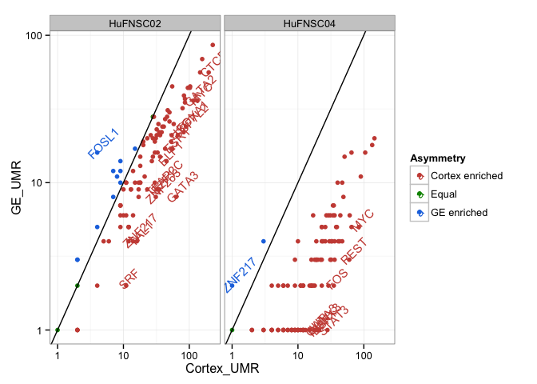

| TF | Cortex02UMR | GE02UMR | Ratio02 | Cortex04UMR | GE04UMR | Ratio04 |
| --- | --- | --- | --- | --- | --- | --- |
| TAF7 | 12 | 4 | 3.00 | 10 | 1 | 10.00 |
| TFAP2A | 30 | 10 | 3.00 | 20 | 3 | 6.67 |
| USF1 | 67 | 21 | 3.19 | 31 | 6 | 5.17 |
| ELF1 | 45 | 14 | 3.21 | 39 | 5 | 7.80 |
| GATA2 | 116 | 36 | 3.22 | 43 | 4 | 10.75 |
| ESR1 | 55 | 17 | 3.24 | 9 | 3 | 3.00 |
| CTCF | 197 | 56 | 3.52 | 105 | 16 | 6.56 |
| TFAP2C | 32 | 9 | 3.56 | 23 | 5 | 4.60 |
| MYC | 133 | 36 | 3.69 | 84 | 5 | 16.80 |
| FOXA1 | 89 | 24 | 3.71 | 26 | 5 | 5.20 |
| TCF7L2 | 82 | 22 | 3.73 | 47 | 4 | 11.75 |
| ZNF263 | 31 | 8 | 3.88 | 23 | 5 | 4.60 |
| E2F1 | 35 | 9 | 3.89 | 38 | 5 | 7.60 |
| TAL1 | 16 | 4 | 4.00 | 5 | 1 | 5.00 |
| GATA3 | 63 | 8 | 7.88 | 18 | 1 | 18.00 |

#### DE genes between Cortex and GE are enriched in neuron development and cell migration

- On average, there are **860** genes differentially expressed between cortex and GE, among them, **454** are upregulated in cortex, and **406** are downregulated.
- **382** Cortex up-regulated genes, and **456** GE up-regulated genes are shared by at least two individuals.
- DAVID enrichment analysis show significant enrichment in **neuronal development** and **cell migration** terms, GE up-regulated genes are enriched in **EGF-related** protein domains as well.
- There are **22** Cortex up-regulated genes, and **26** GE up-regulated genes shared by all four individuals.
- Brain / neuron development related Cortex up-regulated genes (shared by all):
  - SLC1A6: Solute Carrier Family 1 Member 6. Glutamate transporter in cerebellar Purkinje neurons, related to traumatic brain injury.
  - PCDH20: Protocadherin 20. Although its specific function is undetermined, the cadherin-related neuronal receptor is thought to play a role in the establishment and function of specific cell-cell connections in the brain.
  - **GFAP**: *see above.*
  - **ZIC5**: Zic Family Member 5. Essential for neural crest development, converting cells from an epidermal fate to a neural crest cell fate, associated with meningiomas [PMID: 20199689](http://www.ncbi.nlm.nih.gov/pubmed?cmd=search&term=20199689&dopt=b).
  - **ZIC2**: Zic Family Member 2. Related to structural anomaly of the forebrain, and neural tube defects.
  - NEFM: Neurofilament, Medium Polypeptide. Neurofilaments comprise the axoskeleton and functionally maintain neuronal caliber. They may also play a role in intracellular transport to axons and dendrites. This protein is commonly used as a biomarker of neuronal damage.
  - UNC5C: Unc-5 Homolog C. Receptor for netrin required for axon guidance. Mediates axon repulsion of neuronal growth cones in the developing nervous system upon ligand binding.
  - **ADAM19**: ADAM Metallopeptidase Domain 19. Involved in neurogenesis, cell migration, cell adhesion, cell-cell and cell-matrix interactions, serves as a marker for dendritic cell differentiation. UP in primary brain tumors [PMID: 16772875](http://www.ncbi.nlm.nih.gov/pubmed?cmd=search&term=16772875&dopt=b).
- Brain / neuron development related GE up-regulated genes (shared by all):
  - VAX1: Ventral Anterior Homeobox 1. Transcription factor that may function in dorsoventral specification of the forebrain. Required for axon guidance and major tract formation in the developing forebrain.
  - NRXN3: Neurexin 3. Neuronal cell surface protein that may be involved in cell recognition and cell adhesion.
  - **FEZF1**: *see above.*
  - SIX3: SIX Homeobox 3. Plays a role in eye development.
  - ODZ1: Odz, Odd Oz/Ten-M Homolog 1. Involved in neural development, regulating the establishment of proper connectivity within the nervous system.
  - **EPHA3**: EPH Receptor A3. Involved in short-range contact-mediated axon guidance. UP in glioblastoma [PMID: 23410976](http://www.ncbi.nlm.nih.gov/pubmed?cmd=search&term=23410976&dopt=b).
  - **OTX2**: Orthodenticle Homeobox 2. Plays a role in the development of the brain and the sense organs, also influences the proliferation and differentiation of dopaminergic neuronal progenitor cells during mitosis. UP in medulloblastomas [PMID: 20028867](http://www.ncbi.nlm.nih.gov/pubmed?cmd=search&term=20028867&dopt=b).
  - ASTN1: Astrotactin 1. A neuronal adhesion molecule required for glial-guided migration of young postmitotic neuroblasts in cortical regions of developing brain, including cerebrum, hippocampus, cerebellum, and olfactory bulb (Fink et al., 1995).

|  | UP | DN | DE |
| --- | --- | --- | --- |
| HuFNSC01 | 403 | 508 | 911 |
| HuFNSC02 | 588 | 640 | 1228 |
| HuFNSC03 | 447 | 227 | 674 |
| HuFNSC04 | 378 | 249 | 627 |

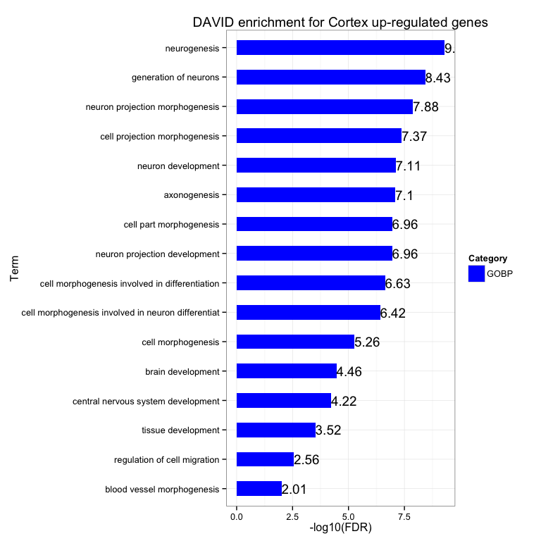

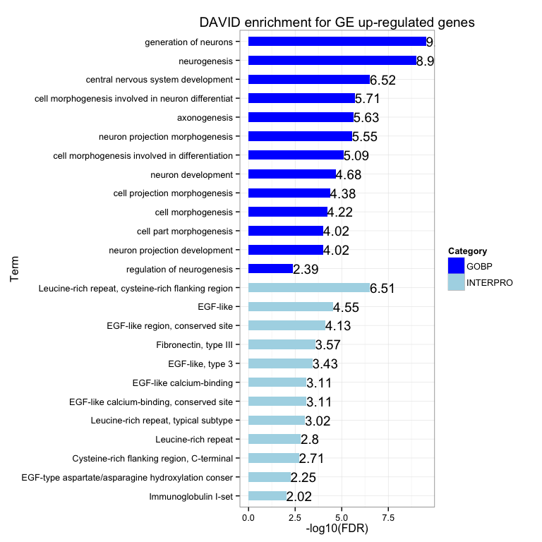

| DE | name | description |
| --- | --- | --- |
| UP | SLC1A6 | solute_carrier_family_1_(high_affinity_aspartate/glutamate_transporter),*member*6 |
| UP | PCDH20 | protocadherin_20 |
| UP | C9orf64 | chromosome_9_open_reading_frame_64 |
| UP | GFAP | glial_fibrillary_acidic_protein |
| UP | ZIC5 | Zic_family_member_5 |
| UP | NEFM | neurofilament,*medium*polypeptide |
| UP | QPCT | glutaminyl-peptide_cyclotransferase |
| UP | UNC5C | unc-5_homolog_C_(C._elegans) |
| UP | ZIC2 | Zic_family_member_2 |
| UP | XKR8 | XK,*Kell*blood_group_complex_subunit-related_family,*member*8 |
| UP | PYGL | phosphorylase,*glycogen,*liver |
| UP | SERINC2 | serine_incorporator_2 |
| UP | KIAA1239 | KIAA1239 |
| UP | B3GALT1 | UDP-Gal:betaGlcNAc_beta_1,3-galactosyltransferase,*polypeptide*1 |
| UP | CCDC48 | coiled-coil_domain_containing_48 |
| UP | NOS1AP | nitric_oxide_synthase_1_(neuronal)*adaptor*protein |
| UP | ADAM19 | ADAM_metallopeptidase_domain_19 |
| UP | H1F0 | H1_histone_family,*member*0 |
| UP | ZIC3 | Zic_family_member_3 |
| UP | NT5E | 5’-nucleotidase,*ecto*(CD73) |
| UP | SYNM | synemin,*intermediate*filament_protein |
| UP | C1orf226 | chromosome_1_open_reading_frame_226 |

| DE | name | description |
| --- | --- | --- |
| DN | DPPA4 | developmental_pluripotency_associated_4 |
| DN | VAX1 | ventral_anterior_homeobox_1 |
| DN | SHISA6 | shisa_homolog_6_(Xenopus_laevis) |
| DN | NRXN3 | neurexin_3 |
| DN | FGFR2 | fibroblast_growth_factor_receptor_2 |
| DN | ST8SIA2 | ST8_alpha-N-acetyl-neuraminide_alpha-2,8-sialyltransferase_2 |
| DN | SLC32A1 | solute_carrier_family_32_(GABA_vesicular_transporter),*member*1 |
| DN | FEZF1 | FEZ_family_zinc_finger_1 |
| DN | AJAP1 | adherens_junctions_associated_protein_1 |
| DN | ZNF703 | zinc_finger_protein_703 |
| DN | VSIG10L | V-set_and_immunoglobulin_domain_containing_10_like |
| DN | SIX3 | SIX_homeobox_3 |
| DN | SORL1 | sortilin-related_receptor,*L(DLR*class)*A*repeats_containing |
| DN | LMO1 | LIM_domain_only_1_(rhombotin_1) |
| DN | ODZ1 | odz,*odd*Oz/ten-m_homolog_1_(Drosophila) |
| DN | EPHA3 | EPH_receptor_A3 |
| DN | TIMP3 | TIMP_metallopeptidase_inhibitor_3 |
| DN | CAMK2N1 | calcium/calmodulin-dependent_protein_kinase_II_inhibitor_1 |
| DN | EEF1A2 | eukaryotic_translation_elongation_factor_1_alpha_2 |
| DN | OTX2 | orthodenticle_homeobox_2 |
| DN | CHL1 | cell_adhesion_molecule_with_homology_to_L1CAM_(close_homolog_of_L1) |
| DN | PCSK1N | proprotein_convertase_subtilisin/kexin_type_1_inhibitor |
| DN | LMO2 | LIM_domain_only_2_(rhombotin-like_1) |
| DN | ASTN1 | astrotactin_1 |
| DN | BASP1 | brain_abundant,*membrane*attached_signal_protein_1 |
| DN | ADCYAP1R1 | adenylate_cyclase_activating_polypeptide_1_(pituitary)*receptor*type_I |

#### Isoforms between Cortex and GE are enriched in cell signaling proteins

- On average, **2054** genes are identified as isoforms between cortex and GE in each individual. **2352** genes are shared in at least two individuals.
- Individual specific isoforms between cortex and GE have **no** significantly enriched terms, suggesting they are more likely random events without biological functions.
- Isoforms shared by at least two individuals are enriched in terms related to **cellular signaling**. InterPro shows enrichment in **EGF protein domain**.

|  | DE_genes | DE_exons | with_expressed_genes | isoform_exons | exclude_DE_genes | isoform_genes |
| --- | --- | --- | --- | --- | --- | --- |
| cortex01_GE01_summary | 911 | 32372 | 18968 | 8440 | 7962 | 2447 |
| cortex02_GE02_summary | 1228 | 35196 | 21880 | 8163 | 7374 | 2298 |
| cortex03_GE03_summary | 674 | 29617 | 13746 | 6401 | 6022 | 2086 |
| cortex04_GE04_summary | 627 | 22386 | 11253 | 4323 | 4259 | 1386 |

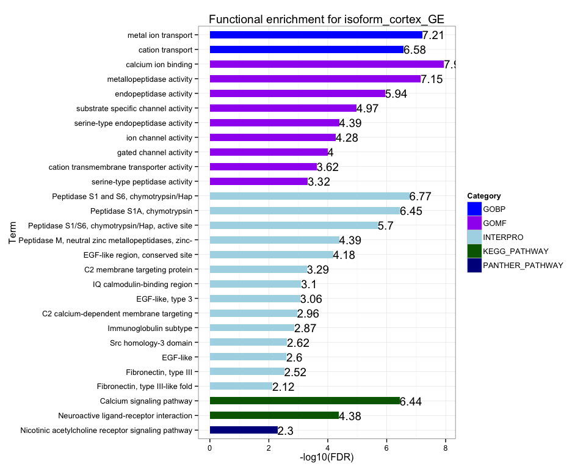

#### Intron retention between Cortex and GE - *TBC*

- *PENDING*

#### mCpG is a stable mark for exon transcription during development

- mCpG at cassette exon boundaries has similar pattern to expressed in both exons.
- mCpG for cassette exons between cortex and GE neurospheres shows no significant differences.
- Results from both WGBS (HuFNSC02 & HuFNSC04) and MeDIP (HuFNSC01 & HuFNSC02) support the assumption that mCpG is a stable mark for exon transcription during development.
- mCpG exon marking is established between neurospheres. *Needs further validation against H1*.

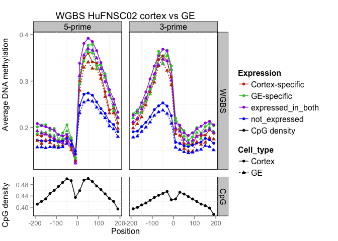

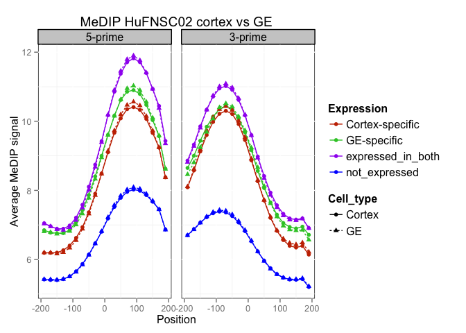

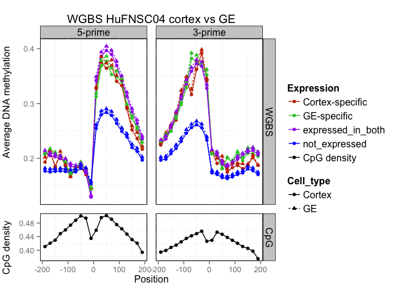

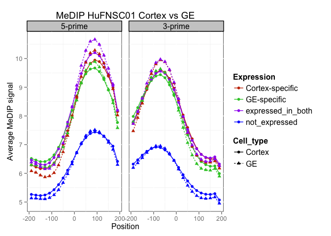

#### H3K36me3 in exon bodies - normalization issue?

- H3K36me3 in expressed in both / not expressed exons shows no significant differences between HuFNSC01 and HuFNSC02.
- H3K36me3 in cassette exons in HuFNSC01 are enriched in GE compared to cortex. However, it is not reproduced in HuFNSC02, where there is no significant differences between cortex and GE. *Not sure what to make of this. Are there any potential bias?*

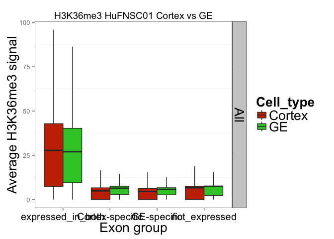

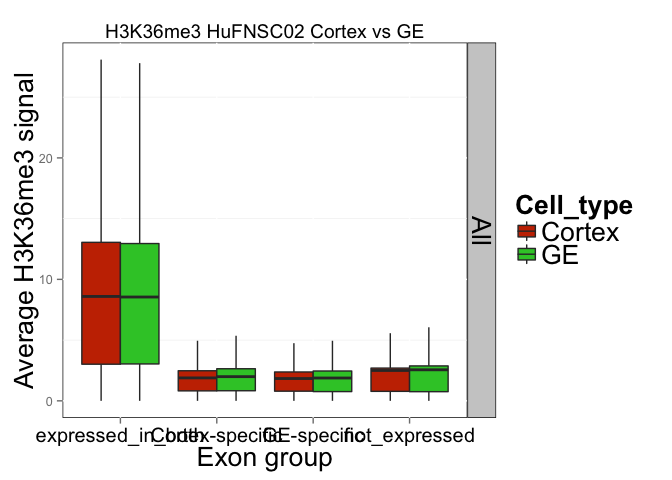

### MZ twins

#### UMR asymmetry between MZ twins in Brain and Cortex

- There is an **asymmetry** between UMRs in HuFNSC01 and HuFNSC02 in the Brain and Cortex neurosphere, but **not** in GE neurosphere. Fold change in total UMR length HuFNSC02/HuFNSC01 in Brain is **2.33**, in Cortex is **1.76**, and in GE is **0.89**.

| Sample | Total.DMR | Hyper.DMR | Hypo.DMR |
| --- | --- | --- | --- |
| Brain-HuFNSC01_Brain-HuFNSC02 | 4472 | 2750 | 1722 |
| Cortex-HuFNSC01_Cortex-HuFNSC02 | 3161 | 1758 | 1403 |
| GE-HuFNSC01_GE-HuFNSC02 | 2716 | 1136 | 1580 |

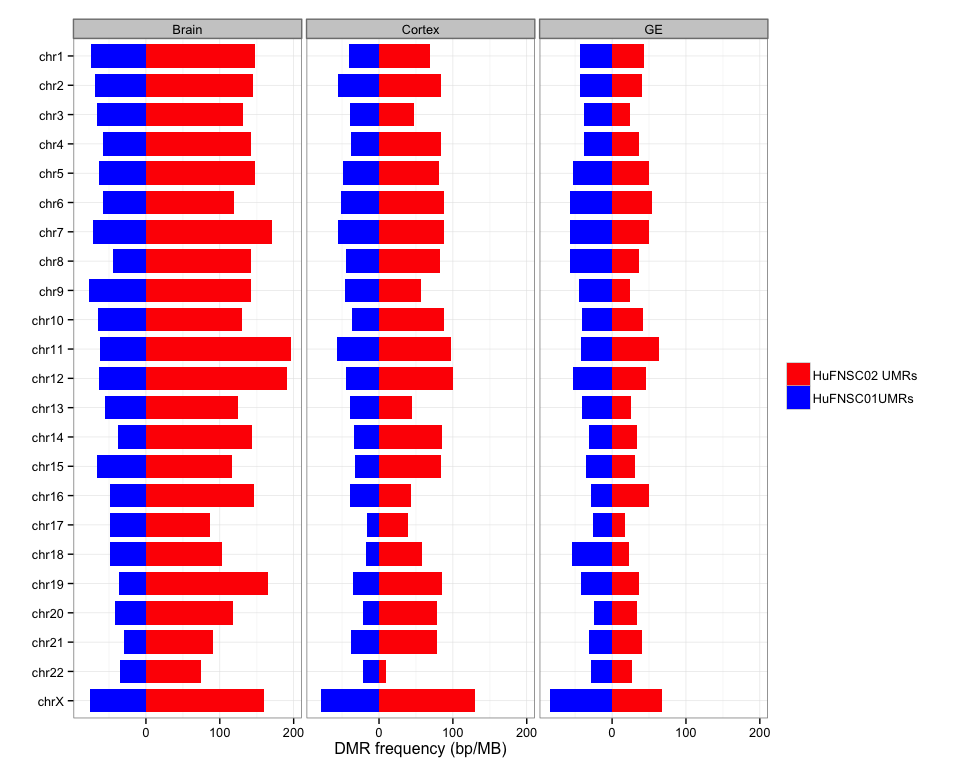

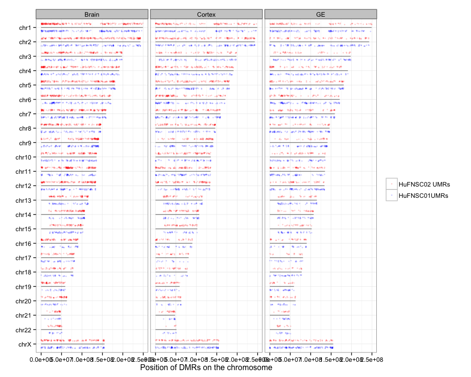

#### GREAT analysis on MZ UMRs are enriched in Homeobox and brain development

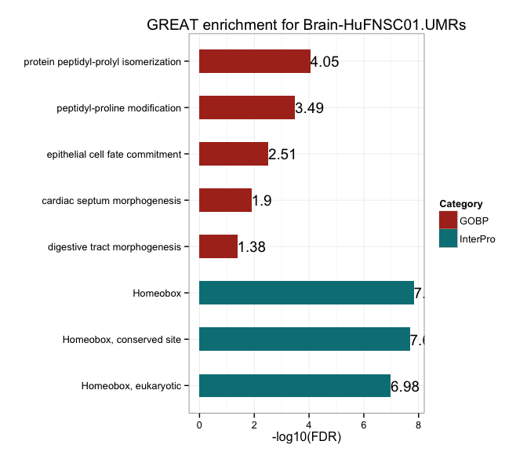

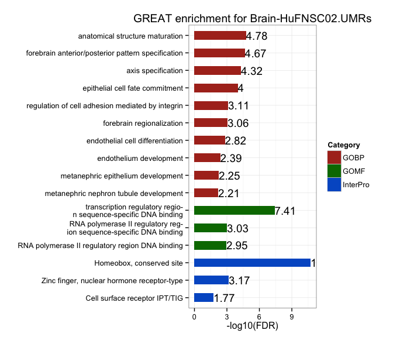

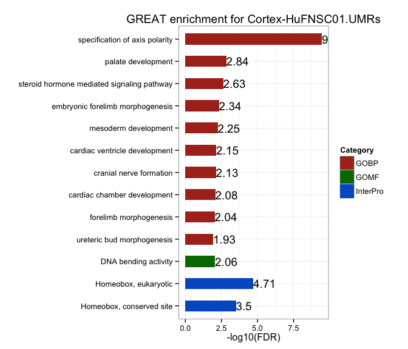

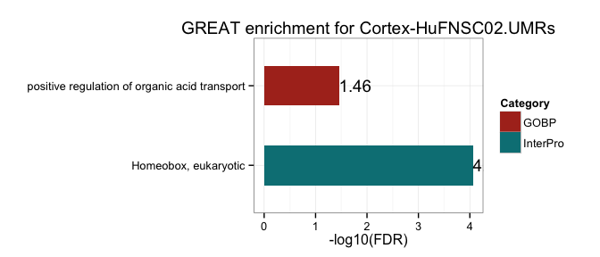

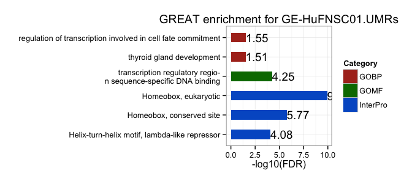

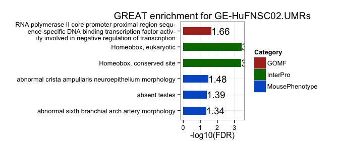

#### UMR breakdown in chromatin states - *TBC*

- **Pending: ChromHMM**

#### MZ UMRs in Brain have less CpGs in CGIs

- Majority of UMR CpGs overlap with genebody, on average **62.59%**. And UMR CpGs are **3-fold** enriched in promoter regions, with on average **34.29%** UMR CpGs are in promoter regions, **39.54%** of CpGs in UMRs overlap with CGIs, **5.34-fold** than expected by random.
- Brain seems to have less CGI/promoter UMRs.

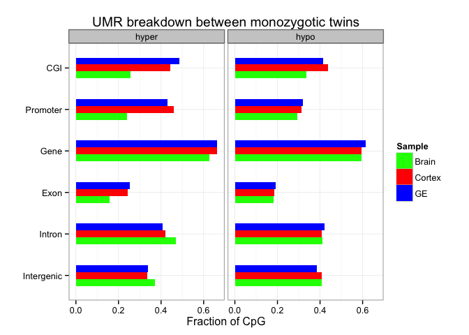

#### DE genes with proximal UMRs between MZ are cell type specific

|  | DMRs | unique.genes | DE.DMRs | unique.DE.genes | same.direction |
| --- | --- | --- | --- | --- | --- |
| Brain01_Brain02_hyper | 432 | 473 | 26 | 26 | 10 |
| Brain01_Brain02_hypo | 367 | 409 | 20 | 20 | 13 |
| Cortex01_Cortex02_hyper | 587 | 659 | 30 | 28 | 17 |
| Cortex01_Cortex02_hypo | 316 | 342 | 24 | 22 | 11 |
| GE01_GE02_hyper | 369 | 402 | 1 | 1 | 1 |
| GE01_GE02_hypo | 361 | 398 | 2 | 2 | 0 |

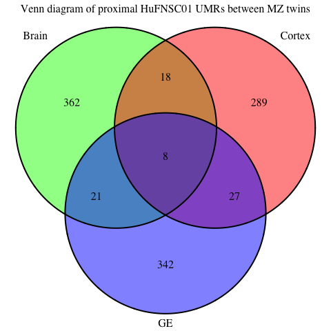

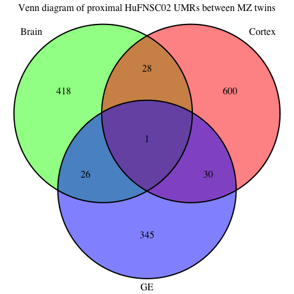

##### HuFNSC01 UMRs proximal associated DE genes

| CellType | name | description | DM | DE |
| --- | --- | --- | --- | --- |
| Brain | SAMD11 | sterile_alpha_motif_domain_containing_11 | hypo | UP |
| Brain | ITGA8 | integrin,*alpha*8 | hypo | UP |
| Brain | EMX2 | empty_spiracles_homeobox_2 | hypo | DN |
| Brain | ARNTL2 | aryl_hydrocarbon_receptor_nuclear_translocator-like_2 | hypo | UP |
| Brain | CPNE8 | copine_VIII | hypo | DN |
| Brain | PCDH17 | protocadherin_17 | hypo | DN |
| Brain |  | Putative_3-phosphoinositide-dependent_protein_kinase_2 | hypo | UP |
| Brain | CPNE7 | copine_VII | hypo | UP |
| Brain | PKDREJ | polycystic_kidney_disease_(polycystin)*and*REJ_homolog_(sperm_receptor_for_egg_jelly_homolog,*sea*urchin) | hypo | UP |
| Brain | THRB | thyroid_hormone_receptor,_beta | hypo | UP |
| Brain | SFRP2 | secreted_frizzled-related_protein_2 | hypo | DN |
| Brain | IER3 | immediate_early_response_3 | hypo | UP |
| Brain | ZBTB12 | zinc_finger_and_BTB_domain_containing_12 | hypo | UP |
| Brain | MDGA1 | MAM_domain_containing_glycosylphosphatidylinositol_anchor_1 | hypo | DN |
| Brain | EPHA1 | EPH_receptor_A1 | hypo | UP |
| Brain |  | Protein_kinase-like_protein_SgK196 | hypo | UP |
| Brain | TOX | thymocyte_selection-associated_high_mobility_group_box | hypo | DN |
| Brain | NCOA2 | nuclear_receptor_coactivator_2 | hypo | UP |
| Brain | GPR64 | G_protein-coupled_receptor_64 | hypo | UP |
| Brain | TRPC5 | transient_receptor_potential_cation_channel,*subfamily*C,*member*5 | hypo | DN |
| Cortex | ELTD1 | EGF,*latrophilin*and_seven_transmembrane_domain_containing_1 | hypo | UP |
| Cortex | CRABP2 | cellular_retinoic_acid_binding_protein_2 | hypo | DN |
| Cortex | SPOCK2 | sparc/osteonectin,*cwcv*and_kazal-like_domains_proteoglycan_(testican)_2 | hypo | DN |
| Cortex | VAX1 | ventral_anterior_homeobox_1 | hypo | UP |
| Cortex | LRRC10B | leucine_rich_repeat_containing_10B | hypo | DN |
| Cortex | NDUFA4L2 | NADH_dehydrogenase_(ubiquinone)*1*alpha_subcomplex,*4-like*2 | hypo | DN |
| Cortex | FOXO1 | forkhead_box_O1 | hypo | UP |
| Cortex | C16orf74 | chromosome_16_open_reading_frame_74 | hypo | DN |
| Cortex | WNT3 | wingless-type_MMTV_integration_site_family,*member*3 | hypo | DN |
| Cortex | CHST9 | carbohydrate_(N-acetylgalactosamine_4-0)*sulfotransferase*9 | hypo | UP |
| Cortex | CD97 | CD97_molecule | hypo | DN |
| Cortex | RNF144A | ring_finger_protein_144A | hypo | UP |
| Cortex | DLX1 | distal-less_homeobox_1 | hypo | UP |
| Cortex | OLIG1 | oligodendrocyte_transcription_factor_1 | hypo | UP |
| Cortex | SCUBE1 | signal_peptide,*CUB*domain,*EGF-like*1 | hypo | DN |
| Cortex | GRIA1 | glutamate_receptor,*ionotropic,*AMPA_1 | hypo | DN |
| Cortex | MMD2 | monocyte_to_macrophage_differentiation-associated_2 | hypo | UP |
| Cortex | SEMA3E | sema_domain,*immunoglobulin*domain_(Ig),*short*basic_domain,*secreted,*(semaphorin)_3E | hypo | DN |
| Cortex | VIPR2 | vasoactive_intestinal_peptide_receptor_2 | hypo | DN |
| Cortex | AP1S2 | adaptor-related_protein_complex_1,*sigma*2_subunit | hypo | DN |
| Cortex | SH3KBP1 | SH3-domain_kinase_binding_protein_1 | hypo | UP |
| GE | FAM5B | family_with_sequence_similarity_5,*member*B | hypo | DN |
| GE | DLL1 | delta-like_1_(Drosophila) | hypo | DN |

##### HuFNSC02 UMRs proximal associated DE genes

| CellType | name | description | DM | DE |
| --- | --- | --- | --- | --- |
| Brain | EPHA8 | EPH_receptor_A8 | hyper | UP |
| Brain | IFI6 | interferon,*alpha-inducible*protein_6 | hyper | DN |
| Brain | BMP8A | bone_morphogenetic_protein_8a | hyper | UP |
| Brain | ALX3 | ALX_homeobox_3 | hyper | UP |
| Brain | NRGN | neurogranin_(protein_kinase_C_substrate,_RC3) | hyper | UP |
| Brain | C1QL4 | complement_component_1,*q*subcomponent-like_4 | hyper | UP |
| Brain | CSRP2 | cysteine_and_glycine-rich_protein_2 | hyper | DN |
| Brain | TTYH2 | tweety_homolog_2_(Drosophila) | hyper | DN |
| Brain | DTNB | dystrobrevin,_beta | hyper | UP |
| Brain | CXCR7 | chemokine_(C-X-C_motif)*receptor*7 | hyper | UP |
| Brain | VHL | von_Hippel-Lindau_tumor_suppressor | hyper | UP |
| Brain | EPHA6 | EPH_receptor_A6 | hyper | UP |
| Brain | CAMK2N2 | calcium/calmodulin-dependent_protein_kinase_II_inhibitor_2 | hyper | UP |
| Brain | TBC1D1 | TBC1_(tre-2/USP6,*BUB2,*cdc16)*domain*family,*member*1 | hyper | DN |
| Brain | NMU | neuromedin_U | hyper | DN |
| Brain | FSTL5 | follistatin-like_5 | hyper | DN |
| Brain | CARTPT | CART_prepropeptide | hyper | DN |
| Brain | EDIL3 | EGF-like_repeats_and_discoidin_I-like_domains_3 | hyper | UP |
| Brain | CCDC90A | coiled-coil_domain_containing_90A | hyper | UP |
| Brain |  | LOC401296_proteinUncharacterized_protein | hyper | UP |
| Brain | NPY | neuropeptide_Y | hyper | UP |
| Brain | SFRP1 | secreted_frizzled-related_protein_1 | hyper | DN |
| Brain | TOX | thymocyte_selection-associated_high_mobility_group_box | hyper | DN |
| Brain | ENTPD2 | ectonucleoside_triphosphate_diphosphohydrolase_2 | hyper | UP |
| Brain | KLHL4 | kelch-like_4_(Drosophila) | hyper | UP |
| Brain | SOX3 | SRY_(sex_determining_region_Y)-box_3 | hyper | DN |
| Cortex | DMRTA2 | DMRT-like_family_A2 | hyper | DN |
| Cortex | NPR1 | natriuretic_peptide_receptor_A/guanylate_cyclase_A_(atrionatriuretic_peptide_receptor_A) | hyper | UP |
| Cortex | PTPRE | protein_tyrosine_phosphatase,*receptor*type,_E | hyper | DN |
| Cortex | PDE3B | phosphodiesterase_3B,_cGMP-inhibited | hyper | UP |
| Cortex | LDHA | lactate_dehydrogenase_A | hyper | DN |
| Cortex | GNG3 | guanine_nucleotide_binding_protein_(G_protein),*gamma*3 | hyper | DN |
| Cortex | METTL7B | methyltransferase_like_7B | hyper | DN |
| Cortex | NME3 | non-metastatic_cells_3,*protein*expressed_in | hyper | DN |
| Cortex | GRIN2A | glutamate_receptor,*ionotropic,*N-methyl_D-aspartate_2A | hyper | UP |
| Cortex | NOL3 | nucleolar_protein_3_(apoptosis_repressor_with_CARD_domain) | hyper | DN |
| Cortex | NR1D1 | nuclear_receptor_subfamily_1,*group*D,*member*1 | hyper | DN |
| Cortex | IGFBP4 | insulin-like_growth_factor_binding_protein_4 | hyper | UP |
| Cortex | TBX2 | T-box_2 | hyper | UP |
| Cortex | LBH | limb_bud_and_heart_development_homolog_(mouse) | hyper | DN |
| Cortex | INSIG2 | insulin_induced_gene_2 | hyper | DN |
| Cortex | WNT7A | wingless-type_MMTV_integration_site_family,*member*7A | hyper | DN |
| Cortex | SNCA | synuclein,*alpha*(non_A4_component_of_amyloid_precursor) | hyper | UP |
| Cortex | NPNT | nephronectin | hyper | DN |
| Cortex | SFRP2 | secreted_frizzled-related_protein_2 | hyper | UP |
| Cortex | PRR16 | proline_rich_16 | hyper | UP |
| Cortex | STC2 | stanniocalcin_2 | hyper | DN |
| Cortex | SNCB | synuclein,_beta | hyper | DN |
| Cortex | ITPR3 | inositol_1,4,5-trisphosphate_receptor,*type*3 | hyper | UP |
| Cortex | NPY | neuropeptide_Y | hyper | DN |
| Cortex | SEMA3D | sema_domain,*immunoglobulin*domain_(Ig),*short*basic_domain,*secreted,*(semaphorin)_3D | hyper | UP |
| Cortex | VGF | VGF_nerve_growth_factor_inducible | hyper | UP |
| Cortex | CAV1 | caveolin_1,*caveolae*protein,_22kDa | hyper | UP |
| Cortex | SHROOM2 | shroom_family_member_2 | hyper | UP |
| GE | DBC1 | deleted_in_bladder_cancer_1 | hyper | DN |